# Machine Learning - Final Project

Philipp Reineke

21 May 2017

## Preparing environment

I first clean the workspace, download the data, load libraries, and set a seed. In this project I use the R libraries “caret”, “ggplot2”, and “doParallel”. My random seed is “123”.

## Creating validation set

Because a lot of training data is available I split the training data into a training and an additional validation dataset. The validation dataset contains 25% of the original training entries.

## Cleaning data

### Removing unavailable entries

I am aware that it’s not permissible to do exploratory data analysis on the test data. However, I think it can be assumed that we will know if a variable will be completely unavailable in the test set (e.g. if we don’t even plan on collecting the variable in the test set). Therefore, I delete all variables in both training and test set for which we don’t have any data in the test set. This has three benefits:

1. I don’t have to impute missing data.
2. It reduces the amount of variables and thereby saves computation time.
3. It reduces the amount of data that needs to be processed and thereby saves RAM, especially during parallelized computations.

### Detecting near zero variables

I try to further reduce complexity of the input data by deleting variables that have almost no variance in the training set.

There is one near zero veraible - “new window”. This is near zero becaus it’s a binary variable indicating whether a new summary window has begun. In the original publication this was a sliding window during which the researcher averaged values. I can’t replicate that merger here because the test data won’t be merge data. So this variable might indeed be superfluous. Therefore I will delete it.

### Deleting counter variable

The training set contains counter variables for each row. I delete them for convenience because then I can just use the “.” operator to include all variables as independent variables in the train functions. If the counter would be included it would perfectly explain automes because its unique per row.

## Exploratory data analysis

### Examining variables

First, I run some simple exploratory analyses using the “str”" and “summary” and functions on the training set.

There are some timestamp values that are redundant. cvtd_timestamp contains all information of raw_timestamp_part_1 and raw_timestamp_part_2. However, cvtd_timestamp is a factor variable. Therefore, preditions might not work if the testing data contains factors that don’t also appear in the training data (i.e. if the testing data has been collected at completely different training sessions). For now I delete the factor variables.

## Exploratory graphs

I also create some exploratory graphs to detect whether variation in the data is more different across users or types of execution.

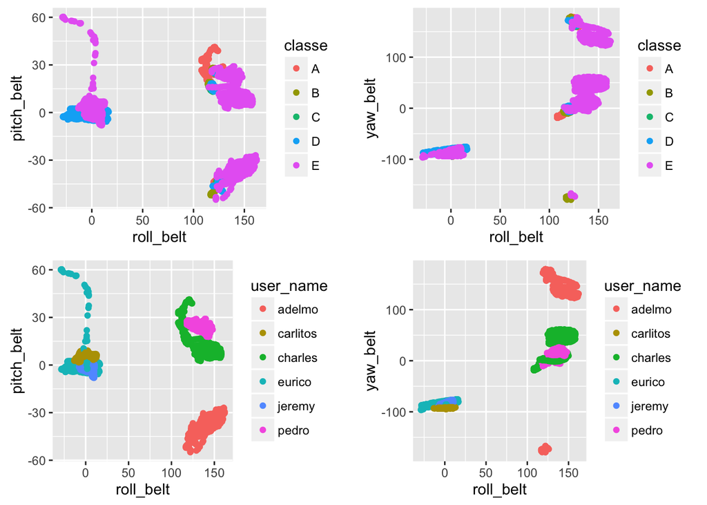

It appears as if there is considerable variance in excercise execution among users and less variance depending on whether the person does the exercise correctly. As such, users need to be included in the prediction algorithm and predictions will be much less accurate if we are predicting the exercises of unknown users.

## Feature detection

Feature detection has already been conducted by the authors of the data. Therefore, I am not doing any additional feature detection.

## Training the algorithm

I am training prediction models using the caret package. I am trying different algorithms and resamples to determine the most accurate approach to predicting the “classe” variable. Because the dependent variable is a factor some prediction algorithms (e.g. linear models) don’t work. I am using the “lda”, “gbm”, “rpart”, and “rf” algorithms and try each with “boot”, “boot632”, “cv”, “repeatedcv” resampling. Because some caret models support parallel processing I am running the computations on multiple cores (1 less than the max amount of cores on my system so as to not block my complete system during the computation). I’m using the parallel backend of the “doParallel” package.

## Evaluating accuracy

One simple metric to detect the estimation error for estimating factor variables is accuracy (share of observations estimated correctly). Therefore, I am determining the accuracy of all algorithms that ran successfully for both the training and the validation set.

```
##        models   resamples              name        timer  share_correct_training  share_correct_validation
## 1         lda        boot          lda_boot   0.42000790               0.7494904                 0.7489779
## 2         gbm        boot          gbm_boot  19.30825195               0.9985052                 0.9983647
## 3       rpart        boot        rpart_boot   0.24133415               0.4978258                 0.4916871
## 4          rf        boot           rf_boot  60.18098803               1.0000000                 1.0000000
## 5         lda     boot632       lda_boot632   0.13134702               0.7494904                 0.7489779
## 6         gbm     boot632       gbm_boot632  19.44878117               0.9986411                 0.9986372
## 7       rpart     boot632     rpart_boot632   0.22360694               0.4978258                 0.4916871
## 8          rf     boot632        rf_boot632  55.87049510               1.0000000                 1.0000000
## 9         lda          cv            lda_cv   0.05637827               0.7494904                 0.7489779
## 10        gbm          cv            gbm_cv   6.06200510               0.9983014                 0.9980921
## 11      rpart          cv          rpart_cv   0.14638478               0.4978258                 0.4916871
## 12         rf          cv             rf_cv  19.59728272               1.0000000                 1.0000000
## 13        lda  repeatedcv    lda_repeatedcv   0.05675586               0.7494904                 0.7489779
## 14        gbm  repeatedcv    gbm_repeatedcv   6.15361155               0.9983014                 0.9980921
## 15      rpart  repeatedcv  rpart_repeatedcv   0.17279262               0.4978258                 0.4916871
## 16         rf  repeatedcv     rf_repeatedcv  21.65022391               1.0000000                 1.0000000
```

The “rf” (Random forest) algorithm seems to be the most successful prediction algorithm for this problem. It achieves perfect prediction accuracy in both test and validation sets, regardless of the resampling method used. Generally, resampling seems to have a negligible impact on accuracy outcomes but a large impact on processing times.

## Creating combined estimator

Creating estimators that combine results of different prediction algorithms does not seem necessary because there are already algorithms that produce perfect results in both the training and the validation sets.

## Running final prediction on testing data

Finally, I use the random forest algorithm with standard bootstrap resampling to predict the test set classes. Since the prediction had perfect accuracy on both the training and the validation set I expect an out of sample error of 0 or very close to it.